```python
!git clone https://github.com/THIYAGU22/udacity-dlnd-generateFaces-GAN.git
```

```
fatal: destination path 'udacity-dlnd-generateFaces-GAN' already exists and is not an empty directory.
```

```python
import os
os.chdir('udacity-dlnd-generateFaces-GAN')
```

# Face Generation

In this project, you'll define and train a DCGAN on a dataset of faces. Your goal is to get a generator network to generate *new* images of faces that look as realistic as possible!

The project will be broken down into a series of tasks from **loading in data to defining and training adversarial networks**. At the end of the notebook, you'll be able to visualize the results of your trained Generator to see how it performs; your generated samples should look like fairly realistic faces with small amounts of noise.

### Get the Data

You'll be using the [CelebFaces Attributes Dataset (CelebA)](http://mmlab.ie.cuhk.edu.hk/projects/CelebA.html) to train your adversarial networks.

This dataset is more complex than the number datasets (like MNIST or SVHN) you've been working with, and so, you should prepare to define deeper networks and train them for a longer time to get good results. It is suggested that you utilize a GPU for training.

### Pre-processed Data

Since the project's main focus is on building the GANs, we've done *some* of the pre-processing for you. Each of the CelebA images has been cropped to remove parts of the image that don't include a face, then resized down to 64x64x3 NumPy images. Some sample data is show below.

[figure not shown]

> If you are working locally, you can download this data [by clicking here](https://s3.amazonaws.com/video.udacity-data.com/topher/2018/November/5be7eb6f_processed-celeba-small/processed-celeba-small.zip)

This is a zip file that you'll need to extract in the home directory of this notebook for further loading and processing. After extracting the data, you should be left with a directory of data `processed_celeba_small/`

```python
!wget https://s3.amazonaws.com/video.udacity-data.com/topher/2018/November/5be7eb6f_processed-celeba-small/processed-celeba-small.zip -O processed_celeba_small.zip
```

```
--2019-04-18 14:57:06--  https://s3.amazonaws.com/video.udacity-data.com/topher/2018/November/5be7eb6f_processed-celeba-small/processed-celeba-small.zip
Resolving s3.amazonaws.com (s3.amazonaws.com)... 52.216.177.197
Connecting to s3.amazonaws.com (s3.amazonaws.com)|52.216.177.197|:443... connected.
HTTP request sent, awaiting response... 200 OK
Length: 247694507 (236M) [application/zip]
Saving to: ‘processed_celeba_small.zip’

processed_celeba_sm 100%[===================>] 236.22M  62.7MB/s    in 3.8s

2019-04-18 14:57:10 (61.4 MB/s) - ‘processed_celeba_small.zip’ saved [247694507/247694507]
```

```python
# can comment out after executing
!unzip processed_celeba_small.zip
```

[output not shown]

```python
data_dir = 'processed_celeba_small/'

"""
DON'T MODIFY ANYTHING IN THIS CELL
"""
import pickle as pkl
import matplotlib.pyplot as plt
import numpy as np
import problem_unittests as tests
#import helper

%matplotlib inline
```

## Visualize the CelebA Data

The [CelebA](http://mmlab.ie.cuhk.edu.hk/projects/CelebA.html) dataset contains over 200,000 celebrity images with annotations. Since you're going to be generating faces, you won't need the annotations, you'll only need the images. Note that these are color images with 3 color channels (RGB)#RGB_Images) each.

### Pre-process and Load the Data

Since the project's main focus is on building the GANs, we've done *some* of the pre-processing for you. Each of the CelebA images has been cropped to remove parts of the image that don't include a face, then resized down to 64x64x3 NumPy images. This *pre-processed* dataset is a smaller subset of the very large CelebA data.

> There are a few other steps that you'll need to **transform** this data and create a **DataLoader**.

#### Exercise: Complete the following `get_dataloader` function, such that it satisfies these requirements:

- Your images should be square, Tensor images of size `image_size x image_size` in the x and y dimension.
- Your function should return a DataLoader that shuffles and batches these Tensor images.

#### ImageFolder

To create a dataset given a directory of images, it's recommended that you use PyTorch's [ImageFolder](https://pytorch.org/docs/stable/torchvision/datasets.html#imagefolder) wrapper, with a root directory `processed_celeba_small/` and data transformation passed in.

```python
# necessary imports
import torch
from torchvision import datasets
from torchvision import transforms
```

```python
def get_dataloader(batch_size, image_size, data_dir='processed_celeba_small/'):
    """
    Batch the neural network data using DataLoader
    :param batch_size: The size of each batch; the number of images in a batch
    :param img_size: The square size of the image data (x, y)
    :param data_dir: Directory where image data is located
    :return: DataLoader with batched data
    """
    transform = transforms.Compose([transforms.Resize(image_size),
                                    transforms.CenterCrop(image_size),
                                   transforms.ToTensor()])
    dataset = datasets.ImageFolder('./'+data_dir,transform)
    # TODO: Implement function and return a dataloader
    dataLoader = torch.utils.data.DataLoader(dataset=dataset,
                                        batch_size = batch_size,
                                        shuffle = True,
                                       num_workers = 0 )

    return dataLoader
```

## Create a DataLoader

#### Exercise: Create a DataLoader `celeba_train_loader` with appropriate hyperparameters.

Call the above function and create a dataloader to view images.

- You can decide on any reasonable `batch_size` parameter
- Your `image_size` **must be** `32`. Resizing the data to a smaller size will make for faster training, while still creating convincing images of faces!

```python
# Define function hyperparameters
batch_size = 128
img_size = 32

"""
DON'T MODIFY ANYTHING IN THIS CELL THAT IS BELOW THIS LINE
"""
# Call your function and get a dataloader
celeba_train_loader = get_dataloader(batch_size, img_size)
```

Next, you can view some images! You should seen square images of somewhat-centered faces.

Note: You'll need to convert the Tensor images into a NumPy type and transpose the dimensions to correctly display an image, suggested `imshow` code is below, but it may not be perfect.

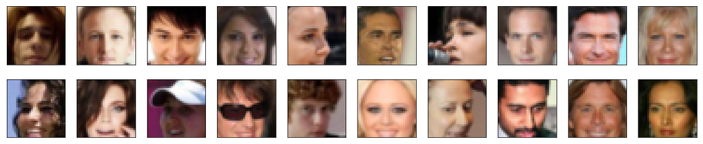

```python
# helper display function
def imshow(img):
    npimg = img.numpy()
    plt.imshow(np.transpose(npimg, (1, 2, 0)))

"""
DON'T MODIFY ANYTHING IN THIS CELL THAT IS BELOW THIS LINE
"""
# obtain one batch of training images
dataiter = iter(celeba_train_loader)
images, _ = dataiter.next() # _ for no labels

# plot the images in the batch, along with the corresponding labels
fig = plt.figure(figsize=(20, 4))
plot_size=20
for idx in np.arange(plot_size):
    ax = fig.add_subplot(2, plot_size/2, idx+1, xticks=[], yticks=[])
    imshow(images[idx])
```

#### Exercise: Pre-process your image data and scale it to a pixel range of -1 to 1

You need to do a bit of pre-processing; you know that the output of a `tanh` activated generator will contain pixel values in a range from -1 to 1, and so, we need to rescale our training images to a range of -1 to 1. (Right now, they are in a range from 0-1.)

```python
# TODO: Complete the scale function
def scale(x, feature_range=(-1, 1)):
    ''' Scale takes in an image x and returns that image, scaled
       with a feature_range of pixel values from -1 to 1.
       This function assumes that the input x is already scaled from 0-1.'''
    # assume x is scaled to (0, 1)
    # scale to feature_range and return scaled x
    min,max = feature_range
    x = x * (max - min) + min
    return x
```

```python
"""
DON'T MODIFY ANYTHING IN THIS CELL THAT IS BELOW THIS LINE
"""
# check scaled range
# should be close to -1 to 1
img = images[0]
scaled_img = scale(img)

print('Min: ', scaled_img.min())
print('Max: ', scaled_img.max())
```

```
Min:  tensor(-1.)
Max:  tensor(0.7176)
```

```python
scaled_img = scale(images[0])
if int(scaled_img.min()) <= 0 and int(scaled_img.max()) >= 0:
    print('it is scaled as expected')
else :
    print('no')
```

```
it is scaled as expected
```

# Define the Model

A GAN is comprised of two adversarial networks, a discriminator and a generator.

## Discriminator

Your first task will be to define the discriminator. This is a convolutional classifier like you've built before, only without any maxpooling layers. To deal with this complex data, it's suggested you use a deep network with **normalization**. You are also allowed to create any helper functions that may be useful.

#### Exercise: Complete the Discriminator class

- The inputs to the discriminator are 32x32x3 tensor images
- The output should be a single value that will indicate whether a given image is real or fake

```python
import torch.nn as nn
import torch.nn.functional as F
```

```python
def conv(in_channels,out_channels,kernel_size,stride=2,padding=1,batch_norm=True):
    layers = []
    conv_layer = nn.Conv2d(in_channels,out_channels,kernel_size,stride,padding,bias=False)
    layers.append(conv_layer)

    if batch_norm:
        layers.append(nn.BatchNorm2d(out_channels))

    return nn.Sequential(*layers)
```

```python
class Discriminator(nn.Module):

    def __init__(self, conv_dim):
        """
        Initialize the Discriminator Module
        :param conv_dim: The depth of the first convolutional layer
        """
        super(Discriminator, self).__init__()

        # complete init function
        self.conv_dim = conv_dim

        self.conv1 = conv(3, conv_dim, 4,batch_norm = False)
        self.conv2 = conv(conv_dim,conv_dim*2, kernel_size = 4)
        self.conv3 = conv(conv_dim*2 , conv_dim*4 ,kernel_size = 4)
        self.conv4 = conv(conv_dim*4,conv_dim*8,kernel_size=4)

        #fc layer
        self.fc = nn.Linear(conv_dim*8*2*2, 1)

    def forward(self, x):
        """
        Forward propagation of the neural network
        :param x: The input to the neural network
        :return: Discriminator logits; the output of the neural network
        """
        # define feedforward behavior
        x = F.leaky_relu(self.conv1(x),0.2)
        x = F.leaky_relu(self.conv2(x),0.2)
        x = F.leaky_relu(self.conv3(x),0.2)
        x = F.leaky_relu(self.conv4(x),0.2)

        x = x.view(-1,self.conv_dim*8*2*2)
        x = self.fc(x)
        return x


"""
DON'T MODIFY ANYTHING IN THIS CELL THAT IS BELOW THIS LINE
"""
tests.test_discriminator(Discriminator)
```

```
Tests Passed
```

## Generator

The generator should upsample an input and generate a *new* image of the same size as our training data `32x32x3`. This should be mostly transpose convolutional layers with normalization applied to the outputs.

#### Exercise: Complete the Generator class

- The inputs to the generator are vectors of some length `z_size`
- The output should be a image of shape `32x32x3`

```python
def deconv(in_channels,out_channels,kernel_size,stride=2,padding=1,batch_norm=True):
    layers = []
    t_conv_layer = nn.ConvTranspose2d(in_channels,out_channels,kernel_size,stride,padding,bias=False)
    layers.append(t_conv_layer)

    if batch_norm:
        layers.append(nn.BatchNorm2d(out_channels))

    return nn.Sequential(*layers)
```

```python
class Generator(nn.Module):

    def __init__(self, z_size, conv_dim):
        """
        Initialize the Generator Module
        :param z_size: The length of the input latent vector, z
        :param conv_dim: The depth of the inputs to the *last* transpose convolutional layer
        """
        super(Generator, self).__init__()

        # complete init function
        self.z_size = z_size
        self.conv_dim = conv_dim

        #first step - fully conn layer
        self.fc = nn.Linear(z_size,conv_dim*8*2*2)

        self.trans_conv1 = deconv(conv_dim*8,conv_dim*4,kernel_size = 4)
        self.trans_conv2 = deconv(conv_dim*4 ,conv_dim*2,kernel_size=4)
        self.trans_conv3 = deconv(conv_dim*2,conv_dim,kernel_size=4)
        self.trans_conv4 = deconv(conv_dim,3,kernel_size=4,batch_norm=False)

    def forward(self, x):
        """
        Forward propagation of the neural network
        :param x: The input to the neural network
        :return: A 32x32x3 Tensor image as output
        """
        # define feedforward behavior
        x = self.fc(x)

        x = x.view(-1,self.conv_dim*8,2,2)
        x= F.relu(self.trans_conv1(x))
        x= F.relu(self.trans_conv2(x))
        x = F.relu(self.trans_conv3(x))

        x = torch.tanh(self.trans_conv4(x))
        return x

"""
DON'T MODIFY ANYTHING IN THIS CELL THAT IS BELOW THIS LINE
"""
tests.test_generator(Generator)
```

```
Tests Passed
```

## Initialize the weights of your networks

To help your models converge, you should initialize the weights of the convolutional and linear layers in your model. From reading the [original DCGAN paper](https://arxiv.org/pdf/1511.06434.pdf), they say:

> All weights were initialized from a zero-centered Normal distribution with standard deviation 0.02.

So, your next task will be to define a weight initialization function that does just this!

You can refer back to the lesson on weight initialization or even consult existing model code, such as that from [the `networks.py` file in CycleGAN Github repository](https://github.com/junyanz/pytorch-CycleGAN-and-pix2pix/blob/master/models/networks.py) to help you complete this function.

#### Exercise: Complete the weight initialization function

- This should initialize only **convolutional** and **linear** layers
- Initialize the weights to a normal distribution, centered around 0, with a standard deviation of 0.02.
- The bias terms, if they exist, may be left alone or set to 0.

```python
def weights_init_normal(m):
    """
    Applies initial weights to certain layers in a model .
    The weights are taken from a normal distribution
    with mean = 0, std dev = 0.02.
    :param m: A module or layer in a network
    """
    # classname will be something like:
    # `Conv`, `BatchNorm2d`, `Linear`, etc.
    classname = m.__class__.__name__

    # TODO: Apply initial weights to convolutional and linear layers
    if hasattr(m, 'weight') and (classname.find('Conv') != -1 or classname.find('Linear') != -1):
        m.weight.data.normal_(0.0, 0.02)
```

## Build complete network

Define your models' hyperparameters and instantiate the discriminator and generator from the classes defined above. Make sure you've passed in the correct input arguments.

```python
"""
DON'T MODIFY ANYTHING IN THIS CELL THAT IS BELOW THIS LINE
"""
def build_network(d_conv_dim, g_conv_dim, z_size):
    # define discriminator and generator
    D = Discriminator(d_conv_dim)
    G = Generator(z_size=z_size, conv_dim=g_conv_dim)

    # initialize model weights
    D.apply(weights_init_normal)
    G.apply(weights_init_normal)

    print(D)
    print()
    print(G)

    return D, G
```

#### Exercise: Define model hyperparameters

```python
# Define model hyperparams
d_conv_dim = 64
g_conv_dim = 64
z_size = 100

"""
DON'T MODIFY ANYTHING IN THIS CELL THAT IS BELOW THIS LINE
"""
D, G = build_network(d_conv_dim, g_conv_dim, z_size)
```

```
Discriminator(
  (conv1): Sequential(
    (0): Conv2d(3, 64, kernel_size=(4, 4), stride=(2, 2), padding=(1, 1), bias=False)
  )
  (conv2): Sequential(
    (0): Conv2d(64, 128, kernel_size=(4, 4), stride=(2, 2), padding=(1, 1), bias=False)
    (1): BatchNorm2d(128, eps=1e-05, momentum=0.1, affine=True, track_running_stats=True)
  )
  (conv3): Sequential(
    (0): Conv2d(128, 256, kernel_size=(4, 4), stride=(2, 2), padding=(1, 1), bias=False)
    (1): BatchNorm2d(256, eps=1e-05, momentum=0.1, affine=True, track_running_stats=True)
  )
  (conv4): Sequential(
    (0): Conv2d(256, 512, kernel_size=(4, 4), stride=(2, 2), padding=(1, 1), bias=False)
    (1): BatchNorm2d(512, eps=1e-05, momentum=0.1, affine=True, track_running_stats=True)
  )
  (fc): Linear(in_features=2048, out_features=1, bias=True)
)

Generator(
  (fc): Linear(in_features=100, out_features=2048, bias=True)
  (trans_conv1): Sequential(
    (0): ConvTranspose2d(512, 256, kernel_size=(4, 4), stride=(2, 2), padding=(1, 1), bias=False)
    (1): BatchNorm2d(256, eps=1e-05, momentum=0.1, affine=True, track_running_stats=True)
  )
  (trans_conv2): Sequential(
    (0): ConvTranspose2d(256, 128, kernel_size=(4, 4), stride=(2, 2), padding=(1, 1), bias=False)
    (1): BatchNorm2d(128, eps=1e-05, momentum=0.1, affine=True, track_running_stats=True)
  )
  (trans_conv3): Sequential(
    (0): ConvTranspose2d(128, 64, kernel_size=(4, 4), stride=(2, 2), padding=(1, 1), bias=False)
    (1): BatchNorm2d(64, eps=1e-05, momentum=0.1, affine=True, track_running_stats=True)
  )
  (trans_conv4): Sequential(
    (0): ConvTranspose2d(64, 3, kernel_size=(4, 4), stride=(2, 2), padding=(1, 1), bias=False)
  )
)
```

### Training on GPU

Check if you can train on GPU. Here, we'll set this as a boolean variable `train_on_gpu`. Later, you'll be responsible for making sure that

> - Models,
> - Model inputs, and
> - Loss function arguments

Are moved to GPU, where appropriate.

```python
"""
DON'T MODIFY ANYTHING IN THIS CELL
"""
import torch

# Check for a GPU
train_on_gpu = torch.cuda.is_available()
if not train_on_gpu:
    print('No GPU found. Please use a GPU to train your neural network.')
else:
    print('Training on GPU!')
```

```
Training on GPU!
```

## Discriminator and Generator Losses

Now we need to calculate the losses for both types of adversarial networks.

### Discriminator Losses

> - For the discriminator, the total loss is the sum of the losses for real and fake images, `d_loss = d_real_loss + d_fake_loss`.
> - Remember that we want the discriminator to output 1 for real images and 0 for fake images, so we need to set up the losses to reflect that.

### Generator Loss

The generator loss will look similar only with flipped labels. The generator's goal is to get the discriminator to *think* its generated images are *real*.

#### Exercise: Complete real and fake loss functions

**You may choose to use either cross entropy or a least squares error loss to complete the following `real_loss` and `fake_loss` functions.**

```python
def real_loss(D_out):
    '''Calculates how close discriminator outputs are to being real.
       param, D_out: discriminator logits
       return: real loss'''
    batch_size = D_out.size(0)

    labels = torch.ones(batch_size)*0.9

    if train_on_gpu:
        labels = labels.cuda()
    criterion = nn.BCEWithLogitsLoss() #cross entropy + logits loss
    loss = criterion(D_out.squeeze(),labels)
    return loss

def fake_loss(D_out):
    '''Calculates how close discriminator outputs are to being fake.
       param, D_out: discriminator logits
       return: fake loss'''
    batch_size = D_out.size(0)

    labels = torch.zeros(batch_size) # fake labels = 0 dummies :)

    if train_on_gpu:
        labels = labels.cuda()
    criterion = nn.BCEWithLogitsLoss() #cross entropy + logits loss
    loss = criterion(D_out.squeeze(),labels)
    return loss
```

## Optimizers

#### Exercise: Define optimizers for your Discriminator (D) and Generator (G)

Define optimizers for your models with appropriate hyperparameters.

```python
lr= 0.0002
beta1 = 0.3
beta2 = 0.999
```

```python
import torch.optim as optim

# Create optimizers for the discriminator D and generator G
d_optimizer = optim.Adam(D.parameters(),lr,[beta1,beta2])
g_optimizer = optim.Adam(G.parameters(),lr,[beta1,beta2])
```

## Training

Training will involve alternating between training the discriminator and the generator. You'll use your functions `real_loss` and `fake_loss` to help you calculate the discriminator losses.

- You should train the discriminator by alternating on real and fake images
- Then the generator, which tries to trick the discriminator and should have an opposing loss function

#### Saving Samples

You've been given some code to print out some loss statistics and save some generated "fake" samples.

#### Exercise: Complete the training function

Keep in mind that, if you've moved your models to GPU, you'll also have to move any model inputs to GPU.

```python
from tqdm import tqdm

from workspace_utils import active_session
```

```python
def train(D, G, n_epochs, print_every=50):
        '''Trains adversarial networks for some number of epochs
           param, D: the discriminator network
           param, G: the generator network
           param, n_epochs: number of epochs to train for
           param, print_every: when to print and record the models' losses
           return: D and G losses'''

        # move models to GPU
        if train_on_gpu:
            D.cuda()
            G.cuda()

        # keep track of loss and generated, "fake" samples
        samples = []
        losses = []

        # Get some fixed data for sampling. These are images that are held
        # constant throughout training, and allow us to inspect the model's performance
        sample_size=16
        fixed_z = np.random.uniform(-1, 1, size=(sample_size, z_size))
        fixed_z = torch.from_numpy(fixed_z).float()
        # move z to GPU if available
        if train_on_gpu:
            fixed_z = fixed_z.cuda()

        # epoch training loop
        for epoch in tqdm(range(n_epochs)):

            # batch training loop
            for batch_i, (real_images, _) in enumerate(celeba_train_loader):

                batch_size = real_images.size(0)
                real_images = scale(real_images)

                # ===============================================
                #         YOUR CODE HERE: TRAIN THE NETWORKS
                # ===============================================
                d_optimizer.zero_grad()

                if train_on_gpu:
                    real_images = real_images.cuda()

                D_real = D(real_images)
                d_real_loss = real_loss(D_real) #if smoothing adjust labels or else 1

                z = np.random.uniform(-1, 1, size=(batch_size, z_size))
                z = torch.from_numpy(z).float()

                if train_on_gpu:
                    z = z.cuda()

                fake_images = G(z) # on the generator to generalize the fake img and to calculate fake loss from discriminator

                D_fake = D(fake_images)
                d_fake_loss = fake_loss(D_fake)



                # 1. Train the discriminator on real and fake images
                d_loss = d_real_loss + d_fake_loss
                d_loss.backward()
                d_optimizer.step()

                #----------------------TRAIN GENERATOR-------------------------

                g_optimizer.zero_grad()

                z = np.random.uniform(-1, 1, size=(batch_size, z_size))
                z = torch.from_numpy(z).float()

                if train_on_gpu:
                    z = z.cuda()

                fake_images = G(z)

                D_fake = D(fake_images)

                # 2. Train the generator with an adversarial loss
                g_loss =  real_loss(D_fake)

                #backpropagate the mistake and update the best possibilities
                g_loss.backward()
                g_optimizer.step()




                # ===============================================
                #              END OF YOUR CODE
                # ===============================================

                # Print some loss stats
                if batch_i % print_every == 0:
                    # append discriminator loss and generator loss
                    losses.append((d_loss.item(), g_loss.item()))
                    # print discriminator and generator loss
                    print('Epoch [{:5d}/{:5d}] | d_loss: {:6.4f} | g_loss: {:6.4f}'.format(
                            epoch+1, n_epochs, d_loss.item(), g_loss.item()))


            ## AFTER EACH EPOCH##
            # this code assumes your generator is named G, feel free to change the name
            # generate and save sample, fake images
            G.eval() # for generating samples
            samples_z = G(fixed_z)
            samples.append(samples_z)
            G.train() # back to training mode

        # Save training generator samples
        with open('train_samples.pkl', 'wb') as f:
            pkl.dump(samples, f)

        # finally return losses
        return losses
```

Set your number of training epochs and train your GAN!

```python
# set number of epochs
n_epochs = 50


"""
DON'T MODIFY ANYTHING IN THIS CELL
"""
# call training function
losses = train(D, G, n_epochs=n_epochs)
```

```
Epoch [    1/   50] | d_loss: 0.8337 | g_loss: 2.1869
Epoch [    1/   50] | d_loss: 0.9226 | g_loss: 1.5720
Epoch [    1/   50] | d_loss: 0.9035 | g_loss: 2.0857
Epoch [    1/   50] | d_loss: 1.0979 | g_loss: 3.1729
Epoch [    1/   50] | d_loss: 0.9663 | g_loss: 2.2689
Epoch [    1/   50] | d_loss: 1.3428 | g_loss: 3.5007
Epoch [    1/   50] | d_loss: 1.2088 | g_loss: 3.7161
Epoch [    1/   50] | d_loss: 0.9914 | g_loss: 1.5404
Epoch [    1/   50] | d_loss: 0.9015 | g_loss: 1.9143
Epoch [    1/   50] | d_loss: 1.0803 | g_loss: 2.4378
Epoch [    1/   50] | d_loss: 0.9122 | g_loss: 1.7198
Epoch [    1/   50] | d_loss: 1.2945 | g_loss: 2.8239
Epoch [    1/   50] | d_loss: 1.0188 | g_loss: 1.5588
Epoch [    1/   50] | d_loss: 0.9764 | g_loss: 1.7555
Epoch [    1/   50] | d_loss: 0.9904 | g_loss: 1.4867
```

```
Epoch [    2/   50] | d_loss: 1.2500 | g_loss: 2.7268
Epoch [    2/   50] | d_loss: 1.1229 | g_loss: 2.0701
Epoch [    2/   50] | d_loss: 0.9163 | g_loss: 1.6274
Epoch [    2/   50] | d_loss: 0.9962 | g_loss: 1.5898
Epoch [    2/   50] | d_loss: 1.1231 | g_loss: 0.8927
Epoch [    2/   50] | d_loss: 1.0183 | g_loss: 1.4684
Epoch [    2/   50] | d_loss: 1.3228 | g_loss: 0.6739
Epoch [    2/   50] | d_loss: 1.0872 | g_loss: 1.0976
Epoch [    2/   50] | d_loss: 1.2447 | g_loss: 2.4153
Epoch [    2/   50] | d_loss: 1.0423 | g_loss: 1.3199
Epoch [    2/   50] | d_loss: 0.9355 | g_loss: 1.4955
Epoch [    2/   50] | d_loss: 1.1305 | g_loss: 1.6315
Epoch [    2/   50] | d_loss: 0.9811 | g_loss: 1.1514
Epoch [    2/   50] | d_loss: 1.4121 | g_loss: 0.9739
Epoch [    2/   50] | d_loss: 1.1949 | g_loss: 2.4230
```

```
Epoch [    3/   50] | d_loss: 1.2239 | g_loss: 0.8645
Epoch [    3/   50] | d_loss: 1.0036 | g_loss: 1.7026
Epoch [    3/   50] | d_loss: 1.0541 | g_loss: 1.8419
Epoch [    3/   50] | d_loss: 1.0705 | g_loss: 1.6746
Epoch [    3/   50] | d_loss: 0.9074 | g_loss: 1.5164
Epoch [    3/   50] | d_loss: 0.9628 | g_loss: 1.2117
Epoch [    3/   50] | d_loss: 1.0944 | g_loss: 1.1294
Epoch [    3/   50] | d_loss: 1.0506 | g_loss: 1.6682
Epoch [    3/   50] | d_loss: 1.3880 | g_loss: 2.1084
Epoch [    3/   50] | d_loss: 0.9452 | g_loss: 1.3460
Epoch [    3/   50] | d_loss: 1.5734 | g_loss: 0.6544
Epoch [    3/   50] | d_loss: 1.2134 | g_loss: 2.1370
Epoch [    3/   50] | d_loss: 0.9069 | g_loss: 1.4635
Epoch [    3/   50] | d_loss: 1.1594 | g_loss: 2.2047
Epoch [    3/   50] | d_loss: 1.0585 | g_loss: 1.4278
```

```
Epoch [    4/   50] | d_loss: 0.9594 | g_loss: 1.3634
Epoch [    4/   50] | d_loss: 0.9726 | g_loss: 1.2408
Epoch [    4/   50] | d_loss: 1.1870 | g_loss: 0.9363
Epoch [    4/   50] | d_loss: 1.0913 | g_loss: 1.1150
Epoch [    4/   50] | d_loss: 1.0327 | g_loss: 1.5893
Epoch [    4/   50] | d_loss: 1.0023 | g_loss: 1.9996
Epoch [    4/   50] | d_loss: 1.0203 | g_loss: 1.8248
Epoch [    4/   50] | d_loss: 0.9508 | g_loss: 1.9233
Epoch [    4/   50] | d_loss: 1.0926 | g_loss: 0.7285
Epoch [    4/   50] | d_loss: 0.9263 | g_loss: 1.4471
Epoch [    4/   50] | d_loss: 1.0908 | g_loss: 2.2297
Epoch [    4/   50] | d_loss: 1.1347 | g_loss: 2.2539
Epoch [    4/   50] | d_loss: 0.8790 | g_loss: 1.3145
Epoch [    4/   50] | d_loss: 0.7974 | g_loss: 1.5845
Epoch [    4/   50] | d_loss: 0.8995 | g_loss: 1.4617
```

```
Epoch [    5/   50] | d_loss: 0.8634 | g_loss: 1.3806
Epoch [    5/   50] | d_loss: 1.1345 | g_loss: 1.2146
Epoch [    5/   50] | d_loss: 0.9929 | g_loss: 0.9399
Epoch [    5/   50] | d_loss: 1.0865 | g_loss: 1.8810
Epoch [    5/   50] | d_loss: 1.0128 | g_loss: 1.1775
Epoch [    5/   50] | d_loss: 1.1490 | g_loss: 2.0402
Epoch [    5/   50] | d_loss: 1.1675 | g_loss: 1.4656
Epoch [    5/   50] | d_loss: 0.8926 | g_loss: 1.0981
Epoch [    5/   50] | d_loss: 1.3096 | g_loss: 2.5735
Epoch [    5/   50] | d_loss: 0.9232 | g_loss: 1.3886
Epoch [    5/   50] | d_loss: 1.2911 | g_loss: 0.8056
Epoch [    5/   50] | d_loss: 0.9960 | g_loss: 1.8352
Epoch [    5/   50] | d_loss: 1.0501 | g_loss: 1.9407
Epoch [    5/   50] | d_loss: 1.0109 | g_loss: 1.2271
Epoch [    5/   50] | d_loss: 1.0442 | g_loss: 1.7062
```

```
Epoch [    6/   50] | d_loss: 0.9696 | g_loss: 1.4109
Epoch [    6/   50] | d_loss: 1.1583 | g_loss: 2.3035
Epoch [    6/   50] | d_loss: 0.9922 | g_loss: 1.1521
Epoch [    6/   50] | d_loss: 1.1181 | g_loss: 1.8060
Epoch [    6/   50] | d_loss: 1.0708 | g_loss: 2.0421
Epoch [    6/   50] | d_loss: 1.0281 | g_loss: 2.1584
Epoch [    6/   50] | d_loss: 1.3003 | g_loss: 2.3097
Epoch [    6/   50] | d_loss: 1.1874 | g_loss: 1.3457
Epoch [    6/   50] | d_loss: 1.1087 | g_loss: 1.8396
Epoch [    6/   50] | d_loss: 0.9152 | g_loss: 2.4952
Epoch [    6/   50] | d_loss: 0.9124 | g_loss: 1.1304
Epoch [    6/   50] | d_loss: 0.9783 | g_loss: 1.5546
Epoch [    6/   50] | d_loss: 0.9239 | g_loss: 2.3112
Epoch [    6/   50] | d_loss: 1.0053 | g_loss: 1.4845
Epoch [    6/   50] | d_loss: 1.0337 | g_loss: 2.3491
```

```
Epoch [    7/   50] | d_loss: 1.0304 | g_loss: 0.9448
Epoch [    7/   50] | d_loss: 1.2766 | g_loss: 0.8699
Epoch [    7/   50] | d_loss: 1.0280 | g_loss: 1.2333
Epoch [    7/   50] | d_loss: 1.1749 | g_loss: 0.9525
Epoch [    7/   50] | d_loss: 0.9591 | g_loss: 1.3307
Epoch [    7/   50] | d_loss: 1.2350 | g_loss: 1.0440
Epoch [    7/   50] | d_loss: 1.1023 | g_loss: 1.9099
Epoch [    7/   50] | d_loss: 0.9285 | g_loss: 1.4559
Epoch [    7/   50] | d_loss: 0.8909 | g_loss: 1.5781
Epoch [    7/   50] | d_loss: 0.9406 | g_loss: 2.0706
Epoch [    7/   50] | d_loss: 0.9714 | g_loss: 1.6530
Epoch [    7/   50] | d_loss: 1.0158 | g_loss: 1.4125
Epoch [    7/   50] | d_loss: 0.8850 | g_loss: 1.6824
Epoch [    7/   50] | d_loss: 0.8916 | g_loss: 1.4332
Epoch [    7/   50] | d_loss: 0.9694 | g_loss: 1.3677
```

```
Epoch [    8/   50] | d_loss: 0.9506 | g_loss: 1.8255
Epoch [    8/   50] | d_loss: 1.0204 | g_loss: 1.6737
Epoch [    8/   50] | d_loss: 1.1781 | g_loss: 1.1028
Epoch [    8/   50] | d_loss: 0.9711 | g_loss: 1.2769
Epoch [    8/   50] | d_loss: 0.9423 | g_loss: 0.9250
Epoch [    8/   50] | d_loss: 0.7790 | g_loss: 1.5628
Epoch [    8/   50] | d_loss: 0.9027 | g_loss: 2.2807
Epoch [    8/   50] | d_loss: 0.9983 | g_loss: 0.9702
Epoch [    8/   50] | d_loss: 0.8341 | g_loss: 1.5259
Epoch [    8/   50] | d_loss: 0.9477 | g_loss: 2.2681
Epoch [    8/   50] | d_loss: 1.0428 | g_loss: 0.9803
Epoch [    8/   50] | d_loss: 0.9761 | g_loss: 1.2956
Epoch [    8/   50] | d_loss: 0.9786 | g_loss: 2.0546
Epoch [    8/   50] | d_loss: 0.9155 | g_loss: 2.1713
Epoch [    8/   50] | d_loss: 0.8446 | g_loss: 1.5071
```

```
Epoch [    9/   50] | d_loss: 0.8618 | g_loss: 1.3928
Epoch [    9/   50] | d_loss: 1.0333 | g_loss: 1.0939
Epoch [    9/   50] | d_loss: 0.9707 | g_loss: 2.4158
Epoch [    9/   50] | d_loss: 0.9280 | g_loss: 1.3167
Epoch [    9/   50] | d_loss: 1.0102 | g_loss: 1.0907
Epoch [    9/   50] | d_loss: 1.0872 | g_loss: 0.7919
Epoch [    9/   50] | d_loss: 0.8553 | g_loss: 1.4817
Epoch [    9/   50] | d_loss: 0.7944 | g_loss: 1.5412
Epoch [    9/   50] | d_loss: 0.7865 | g_loss: 2.0603
Epoch [    9/   50] | d_loss: 1.1703 | g_loss: 2.7457
Epoch [    9/   50] | d_loss: 1.0883 | g_loss: 2.7726
Epoch [    9/   50] | d_loss: 0.8382 | g_loss: 1.8497
Epoch [    9/   50] | d_loss: 1.0006 | g_loss: 1.6178
Epoch [    9/   50] | d_loss: 0.7903 | g_loss: 2.0130
Epoch [    9/   50] | d_loss: 0.8471 | g_loss: 1.2375
```

```
Epoch [   10/   50] | d_loss: 0.9053 | g_loss: 2.4429
Epoch [   10/   50] | d_loss: 0.7288 | g_loss: 1.9494
Epoch [   10/   50] | d_loss: 1.1786 | g_loss: 2.8764
Epoch [   10/   50] | d_loss: 0.7767 | g_loss: 1.8671
Epoch [   10/   50] | d_loss: 0.8680 | g_loss: 1.6610
Epoch [   10/   50] | d_loss: 0.8529 | g_loss: 2.1855
Epoch [   10/   50] | d_loss: 0.6945 | g_loss: 1.8168
Epoch [   10/   50] | d_loss: 1.7652 | g_loss: 0.4144
Epoch [   10/   50] | d_loss: 0.9341 | g_loss: 2.2350
Epoch [   10/   50] | d_loss: 0.9310 | g_loss: 3.4785
Epoch [   10/   50] | d_loss: 0.9535 | g_loss: 1.3859
Epoch [   10/   50] | d_loss: 0.8064 | g_loss: 1.5600
Epoch [   10/   50] | d_loss: 0.7649 | g_loss: 2.2092
Epoch [   10/   50] | d_loss: 0.9467 | g_loss: 2.5520
Epoch [   10/   50] | d_loss: 0.6456 | g_loss: 1.8984
```

```
Epoch [   11/   50] | d_loss: 0.9375 | g_loss: 2.1410
Epoch [   11/   50] | d_loss: 0.7184 | g_loss: 1.6001
Epoch [   11/   50] | d_loss: 0.8342 | g_loss: 1.8864
Epoch [   11/   50] | d_loss: 0.8475 | g_loss: 2.1942
Epoch [   11/   50] | d_loss: 1.1138 | g_loss: 1.2493
Epoch [   11/   50] | d_loss: 0.7147 | g_loss: 1.7251
Epoch [   11/   50] | d_loss: 0.9972 | g_loss: 0.9744
Epoch [   11/   50] | d_loss: 0.7258 | g_loss: 2.5859
Epoch [   11/   50] | d_loss: 0.8847 | g_loss: 2.1719
Epoch [   11/   50] | d_loss: 0.9637 | g_loss: 2.3936
Epoch [   11/   50] | d_loss: 0.7295 | g_loss: 1.8861
Epoch [   11/   50] | d_loss: 0.8288 | g_loss: 1.3567
Epoch [   11/   50] | d_loss: 1.0734 | g_loss: 1.6986
Epoch [   11/   50] | d_loss: 0.7826 | g_loss: 2.3213
Epoch [   11/   50] | d_loss: 0.7832 | g_loss: 1.6999
```

```
Epoch [   12/   50] | d_loss: 1.1754 | g_loss: 3.3452
Epoch [   12/   50] | d_loss: 0.7816 | g_loss: 1.6003
Epoch [   12/   50] | d_loss: 0.9420 | g_loss: 1.2716
Epoch [   12/   50] | d_loss: 0.7769 | g_loss: 1.2194
Epoch [   12/   50] | d_loss: 0.7893 | g_loss: 1.9686
Epoch [   12/   50] | d_loss: 0.7059 | g_loss: 2.2876
Epoch [   12/   50] | d_loss: 0.7974 | g_loss: 1.3251
Epoch [   12/   50] | d_loss: 0.8434 | g_loss: 2.1904
Epoch [   12/   50] | d_loss: 0.7166 | g_loss: 2.3783
Epoch [   12/   50] | d_loss: 0.6690 | g_loss: 2.4500
Epoch [   12/   50] | d_loss: 0.8468 | g_loss: 1.6504
Epoch [   12/   50] | d_loss: 0.6931 | g_loss: 2.1136
Epoch [   12/   50] | d_loss: 0.7205 | g_loss: 2.5546
Epoch [   12/   50] | d_loss: 0.7717 | g_loss: 2.1460
Epoch [   12/   50] | d_loss: 0.7995 | g_loss: 1.4819
```

```
Epoch [   13/   50] | d_loss: 0.8424 | g_loss: 2.7667
Epoch [   13/   50] | d_loss: 0.7632 | g_loss: 2.5380
Epoch [   13/   50] | d_loss: 0.7605 | g_loss: 1.5620
Epoch [   13/   50] | d_loss: 1.3044 | g_loss: 3.2947
Epoch [   13/   50] | d_loss: 0.8826 | g_loss: 2.9123
Epoch [   13/   50] | d_loss: 0.7343 | g_loss: 2.5721
Epoch [   13/   50] | d_loss: 0.6929 | g_loss: 2.0825
Epoch [   13/   50] | d_loss: 0.5896 | g_loss: 2.1091
Epoch [   13/   50] | d_loss: 0.6492 | g_loss: 2.1924
Epoch [   13/   50] | d_loss: 0.7323 | g_loss: 1.8717
Epoch [   13/   50] | d_loss: 0.7945 | g_loss: 2.8315
Epoch [   13/   50] | d_loss: 0.8151 | g_loss: 2.4454
Epoch [   13/   50] | d_loss: 0.6965 | g_loss: 1.6839
Epoch [   13/   50] | d_loss: 0.7187 | g_loss: 1.9467
Epoch [   13/   50] | d_loss: 0.8194 | g_loss: 1.0843
```

```
Epoch [   14/   50] | d_loss: 0.7813 | g_loss: 2.2115
Epoch [   14/   50] | d_loss: 0.6117 | g_loss: 2.4666
Epoch [   14/   50] | d_loss: 0.8957 | g_loss: 0.9769
Epoch [   14/   50] | d_loss: 0.7347 | g_loss: 2.5436
Epoch [   14/   50] | d_loss: 0.7262 | g_loss: 2.7846
Epoch [   14/   50] | d_loss: 0.7591 | g_loss: 1.1312
Epoch [   14/   50] | d_loss: 0.6512 | g_loss: 2.0942
Epoch [   14/   50] | d_loss: 1.1766 | g_loss: 1.2050
Epoch [   14/   50] | d_loss: 0.7274 | g_loss: 1.8560
Epoch [   14/   50] | d_loss: 0.6657 | g_loss: 3.2541
Epoch [   14/   50] | d_loss: 0.6196 | g_loss: 1.9239
Epoch [   14/   50] | d_loss: 0.7494 | g_loss: 1.1859
Epoch [   14/   50] | d_loss: 0.6047 | g_loss: 1.9138
Epoch [   14/   50] | d_loss: 0.7404 | g_loss: 1.8191
Epoch [   14/   50] | d_loss: 0.8182 | g_loss: 3.2573
```

```
Epoch [   15/   50] | d_loss: 0.9364 | g_loss: 1.0622
Epoch [   15/   50] | d_loss: 0.6326 | g_loss: 2.2992
Epoch [   15/   50] | d_loss: 0.7788 | g_loss: 2.3137
Epoch [   15/   50] | d_loss: 0.7099 | g_loss: 1.6860
Epoch [   15/   50] | d_loss: 0.9695 | g_loss: 3.3806
Epoch [   15/   50] | d_loss: 0.9865 | g_loss: 2.7516
Epoch [   15/   50] | d_loss: 0.8089 | g_loss: 1.4136
Epoch [   15/   50] | d_loss: 0.9253 | g_loss: 2.6711
Epoch [   15/   50] | d_loss: 0.6320 | g_loss: 1.9678
Epoch [   15/   50] | d_loss: 0.6716 | g_loss: 2.4337
Epoch [   15/   50] | d_loss: 0.6770 | g_loss: 2.3011
Epoch [   15/   50] | d_loss: 0.6476 | g_loss: 2.1226
Epoch [   15/   50] | d_loss: 0.6663 | g_loss: 2.2930
Epoch [   15/   50] | d_loss: 0.6558 | g_loss: 1.6983
Epoch [   15/   50] | d_loss: 1.0728 | g_loss: 2.9242
```

```
Epoch [   16/   50] | d_loss: 1.7076 | g_loss: 0.9477
Epoch [   16/   50] | d_loss: 0.5483 | g_loss: 2.6123
Epoch [   16/   50] | d_loss: 1.3098 | g_loss: 0.7766
Epoch [   16/   50] | d_loss: 1.0847 | g_loss: 4.3162
Epoch [   16/   50] | d_loss: 0.7139 | g_loss: 1.3399
Epoch [   16/   50] | d_loss: 0.9345 | g_loss: 3.6522
Epoch [   16/   50] | d_loss: 0.5996 | g_loss: 2.0885
Epoch [   16/   50] | d_loss: 0.7046 | g_loss: 2.6682
Epoch [   16/   50] | d_loss: 0.6860 | g_loss: 1.6779
Epoch [   16/   50] | d_loss: 0.9680 | g_loss: 3.5152
Epoch [   16/   50] | d_loss: 0.5740 | g_loss: 2.2371
Epoch [   16/   50] | d_loss: 0.6135 | g_loss: 2.3074
Epoch [   16/   50] | d_loss: 0.6107 | g_loss: 2.8753
Epoch [   16/   50] | d_loss: 0.7978 | g_loss: 1.2132
Epoch [   16/   50] | d_loss: 0.7349 | g_loss: 2.1057
```

```
Epoch [   17/   50] | d_loss: 0.7480 | g_loss: 3.2721
Epoch [   17/   50] | d_loss: 0.5828 | g_loss: 1.9549
Epoch [   17/   50] | d_loss: 0.6019 | g_loss: 2.2875
Epoch [   17/   50] | d_loss: 0.6038 | g_loss: 2.4528
Epoch [   17/   50] | d_loss: 0.5875 | g_loss: 2.3948
Epoch [   17/   50] | d_loss: 0.7926 | g_loss: 1.2936
Epoch [   17/   50] | d_loss: 0.7275 | g_loss: 2.1561
Epoch [   17/   50] | d_loss: 0.5924 | g_loss: 1.8065
Epoch [   17/   50] | d_loss: 0.6456 | g_loss: 2.8087
Epoch [   17/   50] | d_loss: 1.1886 | g_loss: 1.0365
Epoch [   17/   50] | d_loss: 0.7827 | g_loss: 1.5751
Epoch [   17/   50] | d_loss: 0.5423 | g_loss: 2.4680
Epoch [   17/   50] | d_loss: 0.5863 | g_loss: 2.7324
Epoch [   17/   50] | d_loss: 0.5691 | g_loss: 1.5833
Epoch [   17/   50] | d_loss: 0.6846 | g_loss: 2.5374
```

```
Epoch [   18/   50] | d_loss: 0.5938 | g_loss: 1.9161
Epoch [   18/   50] | d_loss: 1.0597 | g_loss: 2.2667
Epoch [   18/   50] | d_loss: 0.5142 | g_loss: 2.7419
Epoch [   18/   50] | d_loss: 0.9130 | g_loss: 3.2492
Epoch [   18/   50] | d_loss: 0.5900 | g_loss: 2.6058
Epoch [   18/   50] | d_loss: 0.5806 | g_loss: 3.2950
Epoch [   18/   50] | d_loss: 0.6197 | g_loss: 2.6913
Epoch [   18/   50] | d_loss: 1.0217 | g_loss: 3.4705
Epoch [   18/   50] | d_loss: 0.8654 | g_loss: 1.6104
Epoch [   18/   50] | d_loss: 0.6665 | g_loss: 2.8692
Epoch [   18/   50] | d_loss: 0.6068 | g_loss: 2.5494
Epoch [   18/   50] | d_loss: 0.6342 | g_loss: 3.0696
Epoch [   18/   50] | d_loss: 0.5149 | g_loss: 1.9957
Epoch [   18/   50] | d_loss: 0.8785 | g_loss: 1.2253
Epoch [   18/   50] | d_loss: 0.5511 | g_loss: 2.5715
```

```
Epoch [   19/   50] | d_loss: 0.6334 | g_loss: 2.7653
Epoch [   19/   50] | d_loss: 0.4771 | g_loss: 2.3338
Epoch [   19/   50] | d_loss: 0.6844 | g_loss: 2.0299
Epoch [   19/   50] | d_loss: 1.2565 | g_loss: 0.5955
Epoch [   19/   50] | d_loss: 0.7450 | g_loss: 2.9805
Epoch [   19/   50] | d_loss: 0.5677 | g_loss: 2.7114
Epoch [   19/   50] | d_loss: 0.5750 | g_loss: 2.3618
Epoch [   19/   50] | d_loss: 0.7662 | g_loss: 3.0524
Epoch [   19/   50] | d_loss: 0.6070 | g_loss: 2.4090
Epoch [   19/   50] | d_loss: 0.5370 | g_loss: 2.9643
Epoch [   19/   50] | d_loss: 0.7815 | g_loss: 1.5624
Epoch [   19/   50] | d_loss: 0.5325 | g_loss: 2.3545
Epoch [   19/   50] | d_loss: 0.6679 | g_loss: 2.6023
Epoch [   19/   50] | d_loss: 0.5873 | g_loss: 2.5951
Epoch [   19/   50] | d_loss: 0.5766 | g_loss: 3.3579
```

```
Epoch [   20/   50] | d_loss: 0.5268 | g_loss: 2.9388
Epoch [   20/   50] | d_loss: 0.6996 | g_loss: 2.0751
Epoch [   20/   50] | d_loss: 2.6586 | g_loss: 3.9595
Epoch [   20/   50] | d_loss: 0.6288 | g_loss: 2.5471
Epoch [   20/   50] | d_loss: 0.5020 | g_loss: 2.4122
Epoch [   20/   50] | d_loss: 0.5547 | g_loss: 2.7339
Epoch [   20/   50] | d_loss: 0.5410 | g_loss: 2.6739
Epoch [   20/   50] | d_loss: 0.5904 | g_loss: 3.5500
Epoch [   20/   50] | d_loss: 0.4949 | g_loss: 2.5208
Epoch [   20/   50] | d_loss: 0.6165 | g_loss: 2.7723
Epoch [   20/   50] | d_loss: 0.5453 | g_loss: 2.4294
Epoch [   20/   50] | d_loss: 1.1645 | g_loss: 0.8889
Epoch [   20/   50] | d_loss: 0.4451 | g_loss: 3.3653
Epoch [   20/   50] | d_loss: 0.6174 | g_loss: 2.0692
Epoch [   20/   50] | d_loss: 0.5527 | g_loss: 2.3682
```

```
Epoch [   21/   50] | d_loss: 0.5573 | g_loss: 2.1842
Epoch [   21/   50] | d_loss: 0.6452 | g_loss: 1.4777
Epoch [   21/   50] | d_loss: 0.6751 | g_loss: 2.0964
Epoch [   21/   50] | d_loss: 0.5545 | g_loss: 3.6640
Epoch [   21/   50] | d_loss: 0.5706 | g_loss: 2.4561
Epoch [   21/   50] | d_loss: 0.5123 | g_loss: 3.7517
Epoch [   21/   50] | d_loss: 0.9098 | g_loss: 1.1507
Epoch [   21/   50] | d_loss: 0.5763 | g_loss: 1.9697
Epoch [   21/   50] | d_loss: 0.5071 | g_loss: 2.5872
Epoch [   21/   50] | d_loss: 0.4928 | g_loss: 2.5054
Epoch [   21/   50] | d_loss: 0.5941 | g_loss: 2.4494
Epoch [   21/   50] | d_loss: 0.5501 | g_loss: 2.5358
Epoch [   21/   50] | d_loss: 0.5556 | g_loss: 2.7163
Epoch [   21/   50] | d_loss: 0.5130 | g_loss: 2.4043
Epoch [   21/   50] | d_loss: 0.6837 | g_loss: 2.9081
```

```
Epoch [   22/   50] | d_loss: 0.4816 | g_loss: 2.3905
Epoch [   22/   50] | d_loss: 0.5400 | g_loss: 2.6285
Epoch [   22/   50] | d_loss: 0.4891 | g_loss: 2.5715
Epoch [   22/   50] | d_loss: 0.6290 | g_loss: 2.1659
Epoch [   22/   50] | d_loss: 0.7576 | g_loss: 2.7888
Epoch [   22/   50] | d_loss: 0.5301 | g_loss: 2.0392
Epoch [   22/   50] | d_loss: 0.4576 | g_loss: 2.6528
Epoch [   22/   50] | d_loss: 0.6062 | g_loss: 1.8014
Epoch [   22/   50] | d_loss: 0.4853 | g_loss: 2.8990
Epoch [   22/   50] | d_loss: 0.5847 | g_loss: 2.1001
Epoch [   22/   50] | d_loss: 0.8217 | g_loss: 2.1835
Epoch [   22/   50] | d_loss: 0.6690 | g_loss: 3.2233
Epoch [   22/   50] | d_loss: 0.9828 | g_loss: 1.5779
Epoch [   22/   50] | d_loss: 0.6142 | g_loss: 2.9681
Epoch [   22/   50] | d_loss: 0.6141 | g_loss: 1.3118
```

```
Epoch [   23/   50] | d_loss: 0.4784 | g_loss: 2.6688
Epoch [   23/   50] | d_loss: 0.4431 | g_loss: 2.9879
Epoch [   23/   50] | d_loss: 0.6747 | g_loss: 3.2695
Epoch [   23/   50] | d_loss: 0.5891 | g_loss: 3.9392
Epoch [   23/   50] | d_loss: 0.7185 | g_loss: 3.4072
Epoch [   23/   50] | d_loss: 0.5026 | g_loss: 2.6002
Epoch [   23/   50] | d_loss: 0.5683 | g_loss: 1.8997
Epoch [   23/   50] | d_loss: 0.5523 | g_loss: 3.1422
Epoch [   23/   50] | d_loss: 0.5081 | g_loss: 2.6420
Epoch [   23/   50] | d_loss: 0.6194 | g_loss: 2.2820
Epoch [   23/   50] | d_loss: 0.8857 | g_loss: 3.9132
Epoch [   23/   50] | d_loss: 0.9213 | g_loss: 3.1912
Epoch [   23/   50] | d_loss: 0.6884 | g_loss: 1.3110
Epoch [   23/   50] | d_loss: 0.6421 | g_loss: 2.3822
Epoch [   23/   50] | d_loss: 0.5177 | g_loss: 2.2820
```

```
Epoch [   24/   50] | d_loss: 0.4569 | g_loss: 3.6401
Epoch [   24/   50] | d_loss: 0.6203 | g_loss: 2.9352
Epoch [   24/   50] | d_loss: 0.7174 | g_loss: 4.2948
Epoch [   24/   50] | d_loss: 0.4166 | g_loss: 3.3197
Epoch [   24/   50] | d_loss: 0.4282 | g_loss: 3.0358
Epoch [   24/   50] | d_loss: 0.4960 | g_loss: 2.8073
Epoch [   24/   50] | d_loss: 0.5313 | g_loss: 3.0837
Epoch [   24/   50] | d_loss: 0.5660 | g_loss: 1.9937
Epoch [   24/   50] | d_loss: 0.4546 | g_loss: 2.6820
Epoch [   24/   50] | d_loss: 0.5658 | g_loss: 2.4063
Epoch [   24/   50] | d_loss: 0.5338 | g_loss: 3.4677
Epoch [   24/   50] | d_loss: 1.1041 | g_loss: 4.6106
Epoch [   24/   50] | d_loss: 0.5844 | g_loss: 2.4930
Epoch [   24/   50] | d_loss: 0.7845 | g_loss: 1.8035
Epoch [   24/   50] | d_loss: 0.5242 | g_loss: 3.4840
```

```
Epoch [   25/   50] | d_loss: 0.5540 | g_loss: 3.9090
Epoch [   25/   50] | d_loss: 0.4938 | g_loss: 1.9990
Epoch [   25/   50] | d_loss: 0.4028 | g_loss: 3.9195
Epoch [   25/   50] | d_loss: 0.5289 | g_loss: 2.4354
Epoch [   25/   50] | d_loss: 0.4254 | g_loss: 3.3510
Epoch [   25/   50] | d_loss: 1.3878 | g_loss: 0.6690
Epoch [   25/   50] | d_loss: 0.5907 | g_loss: 2.7965
Epoch [   25/   50] | d_loss: 0.5671 | g_loss: 2.6385
Epoch [   25/   50] | d_loss: 0.8161 | g_loss: 1.3182
Epoch [   25/   50] | d_loss: 0.6822 | g_loss: 1.7817
Epoch [   25/   50] | d_loss: 0.5667 | g_loss: 2.2147
Epoch [   25/   50] | d_loss: 0.5664 | g_loss: 3.7377
Epoch [   25/   50] | d_loss: 0.4799 | g_loss: 2.7998
Epoch [   25/   50] | d_loss: 0.4695 | g_loss: 2.3110
Epoch [   25/   50] | d_loss: 1.7838 | g_loss: 2.8529
```

```
Epoch [   26/   50] | d_loss: 1.6110 | g_loss: 1.0693
Epoch [   26/   50] | d_loss: 0.4695 | g_loss: 2.1619
Epoch [   26/   50] | d_loss: 0.5044 | g_loss: 2.6499
Epoch [   26/   50] | d_loss: 0.5985 | g_loss: 2.1973
Epoch [   26/   50] | d_loss: 0.4406 | g_loss: 2.6315
Epoch [   26/   50] | d_loss: 0.5404 | g_loss: 3.9292
Epoch [   26/   50] | d_loss: 0.5683 | g_loss: 3.3344
Epoch [   26/   50] | d_loss: 0.5869 | g_loss: 3.7378
Epoch [   26/   50] | d_loss: 0.5629 | g_loss: 2.2492
Epoch [   26/   50] | d_loss: 0.5363 | g_loss: 2.8600
Epoch [   26/   50] | d_loss: 0.4724 | g_loss: 2.8869
Epoch [   26/   50] | d_loss: 0.5531 | g_loss: 2.9844
Epoch [   26/   50] | d_loss: 0.9259 | g_loss: 4.8337
Epoch [   26/   50] | d_loss: 0.5810 | g_loss: 2.6638
Epoch [   26/   50] | d_loss: 0.7023 | g_loss: 1.3785
```

```
Epoch [   27/   50] | d_loss: 1.0964 | g_loss: 2.9695
Epoch [   27/   50] | d_loss: 0.4387 | g_loss: 3.3585
Epoch [   27/   50] | d_loss: 0.4397 | g_loss: 3.1392
Epoch [   27/   50] | d_loss: 0.5454 | g_loss: 3.0347
Epoch [   27/   50] | d_loss: 0.6868 | g_loss: 3.3258
Epoch [   27/   50] | d_loss: 0.4523 | g_loss: 3.0664
Epoch [   27/   50] | d_loss: 0.4545 | g_loss: 2.2378
Epoch [   27/   50] | d_loss: 0.4619 | g_loss: 2.4638
Epoch [   27/   50] | d_loss: 0.5069 | g_loss: 3.2103
Epoch [   27/   50] | d_loss: 0.6236 | g_loss: 1.7246
Epoch [   27/   50] | d_loss: 0.5281 | g_loss: 2.6048
Epoch [   27/   50] | d_loss: 0.5189 | g_loss: 2.1268
Epoch [   27/   50] | d_loss: 0.4402 | g_loss: 3.7790
Epoch [   27/   50] | d_loss: 1.0025 | g_loss: 3.0794
Epoch [   27/   50] | d_loss: 0.5300 | g_loss: 2.2823
```

```
Epoch [   28/   50] | d_loss: 0.5131 | g_loss: 2.1673
Epoch [   28/   50] | d_loss: 0.9668 | g_loss: 2.3519
Epoch [   28/   50] | d_loss: 0.5469 | g_loss: 2.8295
Epoch [   28/   50] | d_loss: 0.4430 | g_loss: 2.9976
Epoch [   28/   50] | d_loss: 0.4836 | g_loss: 4.1559
Epoch [   28/   50] | d_loss: 0.5119 | g_loss: 3.3009
Epoch [   28/   50] | d_loss: 0.4292 | g_loss: 3.1152
Epoch [   28/   50] | d_loss: 0.5216 | g_loss: 3.1190
Epoch [   28/   50] | d_loss: 0.5003 | g_loss: 2.2028
Epoch [   28/   50] | d_loss: 0.4374 | g_loss: 3.5197
Epoch [   28/   50] | d_loss: 0.4258 | g_loss: 3.4740
Epoch [   28/   50] | d_loss: 0.4663 | g_loss: 3.2739
Epoch [   28/   50] | d_loss: 0.4611 | g_loss: 3.0938
Epoch [   28/   50] | d_loss: 0.5330 | g_loss: 1.9164
Epoch [   28/   50] | d_loss: 0.5474 | g_loss: 2.5039
```

```
Epoch [   29/   50] | d_loss: 0.4817 | g_loss: 2.6934
Epoch [   29/   50] | d_loss: 0.4226 | g_loss: 3.4457
Epoch [   29/   50] | d_loss: 0.6290 | g_loss: 3.0305
Epoch [   29/   50] | d_loss: 0.4331 | g_loss: 2.6302
Epoch [   29/   50] | d_loss: 0.8109 | g_loss: 1.8298
Epoch [   29/   50] | d_loss: 0.3830 | g_loss: 3.7401
Epoch [   29/   50] | d_loss: 0.4729 | g_loss: 3.2118
Epoch [   29/   50] | d_loss: 0.5204 | g_loss: 2.4693
Epoch [   29/   50] | d_loss: 0.4890 | g_loss: 2.4751
Epoch [   29/   50] | d_loss: 0.4640 | g_loss: 4.1139
Epoch [   29/   50] | d_loss: 0.4042 | g_loss: 3.6721
Epoch [   29/   50] | d_loss: 1.2375 | g_loss: 1.1537
Epoch [   29/   50] | d_loss: 0.4819 | g_loss: 3.0825
Epoch [   29/   50] | d_loss: 0.5424 | g_loss: 2.5987
Epoch [   29/   50] | d_loss: 0.5029 | g_loss: 2.8669
```

```
Epoch [   30/   50] | d_loss: 0.4660 | g_loss: 2.0070
Epoch [   30/   50] | d_loss: 0.4134 | g_loss: 4.4088
Epoch [   30/   50] | d_loss: 0.5356 | g_loss: 2.1325
Epoch [   30/   50] | d_loss: 0.4802 | g_loss: 2.9075
Epoch [   30/   50] | d_loss: 0.6157 | g_loss: 4.3695
Epoch [   30/   50] | d_loss: 0.8437 | g_loss: 3.0689
Epoch [   30/   50] | d_loss: 0.4632 | g_loss: 2.3275
Epoch [   30/   50] | d_loss: 0.4786 | g_loss: 3.4520
Epoch [   30/   50] | d_loss: 0.7060 | g_loss: 5.3638
Epoch [   30/   50] | d_loss: 0.5374 | g_loss: 3.4181
Epoch [   30/   50] | d_loss: 0.4389 | g_loss: 2.9904
Epoch [   30/   50] | d_loss: 0.5347 | g_loss: 2.4031
Epoch [   30/   50] | d_loss: 1.5747 | g_loss: 0.4986
Epoch [   30/   50] | d_loss: 0.4777 | g_loss: 3.3663
Epoch [   30/   50] | d_loss: 0.7280 | g_loss: 1.9005
```

```
Epoch [   31/   50] | d_loss: 0.4399 | g_loss: 2.5530
Epoch [   31/   50] | d_loss: 0.4222 | g_loss: 3.9494
Epoch [   31/   50] | d_loss: 0.4145 | g_loss: 3.6495
Epoch [   31/   50] | d_loss: 0.4242 | g_loss: 2.6751
Epoch [   31/   50] | d_loss: 0.4423 | g_loss: 4.1207
Epoch [   31/   50] | d_loss: 0.4029 | g_loss: 3.2936
Epoch [   31/   50] | d_loss: 0.5416 | g_loss: 2.1493
Epoch [   31/   50] | d_loss: 0.4460 | g_loss: 3.1040
Epoch [   31/   50] | d_loss: 0.6708 | g_loss: 3.5156
Epoch [   31/   50] | d_loss: 0.9285 | g_loss: 4.6347
Epoch [   31/   50] | d_loss: 1.1328 | g_loss: 3.9688
Epoch [   31/   50] | d_loss: 0.5096 | g_loss: 3.0296
Epoch [   31/   50] | d_loss: 0.4977 | g_loss: 2.9990
Epoch [   31/   50] | d_loss: 0.4402 | g_loss: 3.7320
Epoch [   31/   50] | d_loss: 0.5114 | g_loss: 2.3012
```

```
Epoch [   32/   50] | d_loss: 0.6915 | g_loss: 1.6081
Epoch [   32/   50] | d_loss: 0.4121 | g_loss: 2.9226
Epoch [   32/   50] | d_loss: 0.5378 | g_loss: 2.1056
Epoch [   32/   50] | d_loss: 0.4467 | g_loss: 4.0475
Epoch [   32/   50] | d_loss: 0.4496 | g_loss: 3.4075
Epoch [   32/   50] | d_loss: 0.6185 | g_loss: 2.3982
Epoch [   32/   50] | d_loss: 0.5794 | g_loss: 2.4463
Epoch [   32/   50] | d_loss: 0.4499 | g_loss: 3.3997
Epoch [   32/   50] | d_loss: 0.4492 | g_loss: 2.8540
Epoch [   32/   50] | d_loss: 0.4216 | g_loss: 3.5585
Epoch [   32/   50] | d_loss: 0.4869 | g_loss: 1.9462
Epoch [   32/   50] | d_loss: 0.5258 | g_loss: 3.1540
Epoch [   32/   50] | d_loss: 0.4222 | g_loss: 2.7249
Epoch [   32/   50] | d_loss: 1.2296 | g_loss: 5.3130
Epoch [   32/   50] | d_loss: 0.4612 | g_loss: 2.9440
```

```
Epoch [   33/   50] | d_loss: 1.1730 | g_loss: 3.3999
Epoch [   33/   50] | d_loss: 0.5014 | g_loss: 3.4763
Epoch [   33/   50] | d_loss: 0.4871 | g_loss: 2.5943
Epoch [   33/   50] | d_loss: 0.6516 | g_loss: 4.2216
Epoch [   33/   50] | d_loss: 0.4434 | g_loss: 2.6543
Epoch [   33/   50] | d_loss: 0.4035 | g_loss: 3.7518
Epoch [   33/   50] | d_loss: 0.5260 | g_loss: 2.8112
Epoch [   33/   50] | d_loss: 0.4330 | g_loss: 2.5047
Epoch [   33/   50] | d_loss: 0.4125 | g_loss: 3.3561
Epoch [   33/   50] | d_loss: 0.5926 | g_loss: 4.0484
Epoch [   33/   50] | d_loss: 0.8656 | g_loss: 1.9179
Epoch [   33/   50] | d_loss: 0.4206 | g_loss: 2.8169
Epoch [   33/   50] | d_loss: 0.5125 | g_loss: 4.3464
Epoch [   33/   50] | d_loss: 0.4543 | g_loss: 2.8449
Epoch [   33/   50] | d_loss: 0.4368 | g_loss: 3.2219
```

```
Epoch [   34/   50] | d_loss: 0.4830 | g_loss: 3.0204
Epoch [   34/   50] | d_loss: 0.4511 | g_loss: 2.9122
Epoch [   34/   50] | d_loss: 0.3867 | g_loss: 3.7521
Epoch [   34/   50] | d_loss: 0.4576 | g_loss: 2.6154
Epoch [   34/   50] | d_loss: 0.6233 | g_loss: 3.9915
Epoch [   34/   50] | d_loss: 0.9951 | g_loss: 4.1269
Epoch [   34/   50] | d_loss: 0.4436 | g_loss: 3.6576
Epoch [   34/   50] | d_loss: 0.4526 | g_loss: 2.9619
Epoch [   34/   50] | d_loss: 0.5136 | g_loss: 2.2717
Epoch [   34/   50] | d_loss: 0.4955 | g_loss: 3.6147
Epoch [   34/   50] | d_loss: 0.4200 | g_loss: 3.7242
Epoch [   34/   50] | d_loss: 0.5741 | g_loss: 1.2036
Epoch [   34/   50] | d_loss: 0.4119 | g_loss: 3.6075
Epoch [   34/   50] | d_loss: 0.4833 | g_loss: 2.7661
Epoch [   34/   50] | d_loss: 0.3840 | g_loss: 3.9256
```

```
Epoch [   35/   50] | d_loss: 0.4511 | g_loss: 4.1850
Epoch [   35/   50] | d_loss: 0.4568 | g_loss: 4.5441
Epoch [   35/   50] | d_loss: 0.4063 | g_loss: 3.5308
Epoch [   35/   50] | d_loss: 0.3916 | g_loss: 3.9382
Epoch [   35/   50] | d_loss: 0.4845 | g_loss: 2.5714
Epoch [   35/   50] | d_loss: 0.5100 | g_loss: 2.5989
Epoch [   35/   50] | d_loss: 0.4631 | g_loss: 4.8084
Epoch [   35/   50] | d_loss: 0.3803 | g_loss: 4.0541
Epoch [   35/   50] | d_loss: 1.1487 | g_loss: 1.0877
Epoch [   35/   50] | d_loss: 0.4371 | g_loss: 2.3672
Epoch [   35/   50] | d_loss: 0.4845 | g_loss: 3.0969
Epoch [   35/   50] | d_loss: 0.7031 | g_loss: 2.0470
Epoch [   35/   50] | d_loss: 0.4788 | g_loss: 4.1434
Epoch [   35/   50] | d_loss: 0.4509 | g_loss: 3.8716
Epoch [   35/   50] | d_loss: 0.5004 | g_loss: 2.6506
```

```
Epoch [   36/   50] | d_loss: 0.5460 | g_loss: 1.8959
Epoch [   36/   50] | d_loss: 0.4359 | g_loss: 3.9851
Epoch [   36/   50] | d_loss: 1.1171 | g_loss: 0.7780
Epoch [   36/   50] | d_loss: 0.4211 | g_loss: 3.0030
Epoch [   36/   50] | d_loss: 0.5315 | g_loss: 2.0981
Epoch [   36/   50] | d_loss: 0.4374 | g_loss: 2.2660
Epoch [   36/   50] | d_loss: 0.6275 | g_loss: 2.1777
Epoch [   36/   50] | d_loss: 0.4495 | g_loss: 2.7860
Epoch [   36/   50] | d_loss: 0.4396 | g_loss: 3.2047
Epoch [   36/   50] | d_loss: 0.4447 | g_loss: 2.3341
Epoch [   36/   50] | d_loss: 0.4030 | g_loss: 4.4355
Epoch [   36/   50] | d_loss: 0.5418 | g_loss: 2.3344
Epoch [   36/   50] | d_loss: 0.4091 | g_loss: 3.8501
Epoch [   36/   50] | d_loss: 0.3783 | g_loss: 4.1227
Epoch [   36/   50] | d_loss: 0.4703 | g_loss: 3.4926
```

```
Epoch [   37/   50] | d_loss: 0.9355 | g_loss: 4.0092
Epoch [   37/   50] | d_loss: 0.4256 | g_loss: 3.1899
Epoch [   37/   50] | d_loss: 0.4340 | g_loss: 3.3032
Epoch [   37/   50] | d_loss: 0.4562 | g_loss: 2.8080
Epoch [   37/   50] | d_loss: 0.4154 | g_loss: 3.1315
Epoch [   37/   50] | d_loss: 0.4337 | g_loss: 4.0922
Epoch [   37/   50] | d_loss: 0.4712 | g_loss: 3.5360
Epoch [   37/   50] | d_loss: 0.5876 | g_loss: 3.6791
Epoch [   37/   50] | d_loss: 0.5363 | g_loss: 2.8317
Epoch [   37/   50] | d_loss: 0.5353 | g_loss: 2.1229
Epoch [   37/   50] | d_loss: 0.6226 | g_loss: 4.0863
Epoch [   37/   50] | d_loss: 0.4934 | g_loss: 3.5283
Epoch [   37/   50] | d_loss: 0.4606 | g_loss: 3.3106
Epoch [   37/   50] | d_loss: 0.5567 | g_loss: 4.2204
Epoch [   37/   50] | d_loss: 0.3925 | g_loss: 2.7567
```

```
Epoch [   38/   50] | d_loss: 0.4552 | g_loss: 3.0690
Epoch [   38/   50] | d_loss: 0.6114 | g_loss: 2.3843
Epoch [   38/   50] | d_loss: 0.4080 | g_loss: 3.2866
Epoch [   38/   50] | d_loss: 0.4030 | g_loss: 4.1134
Epoch [   38/   50] | d_loss: 0.5594 | g_loss: 4.3520
Epoch [   38/   50] | d_loss: 0.8180 | g_loss: 1.9633
Epoch [   38/   50] | d_loss: 0.5204 | g_loss: 2.1521
Epoch [   38/   50] | d_loss: 0.4156 | g_loss: 3.6274
Epoch [   38/   50] | d_loss: 0.4067 | g_loss: 3.3103
Epoch [   38/   50] | d_loss: 0.4503 | g_loss: 2.8280
Epoch [   38/   50] | d_loss: 0.3978 | g_loss: 3.4023
Epoch [   38/   50] | d_loss: 0.4780 | g_loss: 2.9582
Epoch [   38/   50] | d_loss: 0.4371 | g_loss: 3.3602
Epoch [   38/   50] | d_loss: 0.5530 | g_loss: 2.4808
Epoch [   38/   50] | d_loss: 0.5357 | g_loss: 2.9089
```

```
Epoch [   39/   50] | d_loss: 0.4278 | g_loss: 2.9958
Epoch [   39/   50] | d_loss: 0.3851 | g_loss: 3.9950
Epoch [   39/   50] | d_loss: 0.4354 | g_loss: 3.9633
Epoch [   39/   50] | d_loss: 0.4602 | g_loss: 2.9457
Epoch [   39/   50] | d_loss: 0.5082 | g_loss: 2.5064
Epoch [   39/   50] | d_loss: 0.4199 | g_loss: 4.0924
Epoch [   39/   50] | d_loss: 0.5489 | g_loss: 1.5350
Epoch [   39/   50] | d_loss: 0.4380 | g_loss: 3.0867
Epoch [   39/   50] | d_loss: 0.4290 | g_loss: 4.3276
Epoch [   39/   50] | d_loss: 0.8634 | g_loss: 0.7564
Epoch [   39/   50] | d_loss: 0.5150 | g_loss: 1.9934
Epoch [   39/   50] | d_loss: 1.0346 | g_loss: 3.4018
Epoch [   39/   50] | d_loss: 0.3852 | g_loss: 4.3511
Epoch [   39/   50] | d_loss: 1.0147 | g_loss: 2.2538
Epoch [   39/   50] | d_loss: 0.4300 | g_loss: 3.3304
```

```
Epoch [   40/   50] | d_loss: 0.4286 | g_loss: 3.3223
Epoch [   40/   50] | d_loss: 0.4135 | g_loss: 3.4608
Epoch [   40/   50] | d_loss: 0.4513 | g_loss: 3.3325
Epoch [   40/   50] | d_loss: 0.5735 | g_loss: 2.0293
Epoch [   40/   50] | d_loss: 0.4950 | g_loss: 4.1688
Epoch [   40/   50] | d_loss: 0.8301 | g_loss: 1.0017
Epoch [   40/   50] | d_loss: 0.3947 | g_loss: 3.2169
Epoch [   40/   50] | d_loss: 0.4930 | g_loss: 4.6857
Epoch [   40/   50] | d_loss: 0.8379 | g_loss: 1.6820
Epoch [   40/   50] | d_loss: 0.4631 | g_loss: 3.2527
Epoch [   40/   50] | d_loss: 0.4193 | g_loss: 3.2891
Epoch [   40/   50] | d_loss: 0.3908 | g_loss: 4.4102
Epoch [   40/   50] | d_loss: 0.4954 | g_loss: 2.9653
Epoch [   40/   50] | d_loss: 0.4114 | g_loss: 4.3611
Epoch [   40/   50] | d_loss: 0.4616 | g_loss: 2.2236
```

```
Epoch [   41/   50] | d_loss: 0.4243 | g_loss: 3.7538
Epoch [   41/   50] | d_loss: 0.4135 | g_loss: 3.3839
Epoch [   41/   50] | d_loss: 0.4414 | g_loss: 2.1364
Epoch [   41/   50] | d_loss: 0.3849 | g_loss: 4.0459
Epoch [   41/   50] | d_loss: 0.4150 | g_loss: 3.0750
Epoch [   41/   50] | d_loss: 0.4416 | g_loss: 4.0479
Epoch [   41/   50] | d_loss: 0.6600 | g_loss: 1.8274
Epoch [   41/   50] | d_loss: 0.4654 | g_loss: 3.3034
Epoch [   41/   50] | d_loss: 0.4064 | g_loss: 3.3595
Epoch [   41/   50] | d_loss: 0.5857 | g_loss: 2.4906
Epoch [   41/   50] | d_loss: 1.1434 | g_loss: 1.4607
Epoch [   41/   50] | d_loss: 0.4658 | g_loss: 2.2487
Epoch [   41/   50] | d_loss: 0.3821 | g_loss: 3.7671
Epoch [   41/   50] | d_loss: 0.4856 | g_loss: 3.6967
Epoch [   41/   50] | d_loss: 0.3970 | g_loss: 4.2802
```

```
Epoch [   42/   50] | d_loss: 0.4193 | g_loss: 4.2967
Epoch [   42/   50] | d_loss: 0.4010 | g_loss: 4.0805
Epoch [   42/   50] | d_loss: 0.4035 | g_loss: 3.6462
Epoch [   42/   50] | d_loss: 0.4173 | g_loss: 3.8595
Epoch [   42/   50] | d_loss: 0.5775 | g_loss: 3.4697
Epoch [   42/   50] | d_loss: 0.4049 | g_loss: 3.1451
Epoch [   42/   50] | d_loss: 0.4308 | g_loss: 3.2552
Epoch [   42/   50] | d_loss: 0.3960 | g_loss: 4.1338
Epoch [   42/   50] | d_loss: 0.4612 | g_loss: 3.3637
Epoch [   42/   50] | d_loss: 0.4348 | g_loss: 4.4253
Epoch [   42/   50] | d_loss: 0.4005 | g_loss: 4.1674
Epoch [   42/   50] | d_loss: 0.5680 | g_loss: 3.0792
Epoch [   42/   50] | d_loss: 0.4280 | g_loss: 3.6183
Epoch [   42/   50] | d_loss: 0.4104 | g_loss: 3.1923
Epoch [   42/   50] | d_loss: 0.4382 | g_loss: 2.9595
```

```
Epoch [   43/   50] | d_loss: 0.4725 | g_loss: 4.4216
Epoch [   43/   50] | d_loss: 0.4020 | g_loss: 4.2214
Epoch [   43/   50] | d_loss: 0.3814 | g_loss: 4.1297
Epoch [   43/   50] | d_loss: 0.3895 | g_loss: 4.6546
Epoch [   43/   50] | d_loss: 0.4495 | g_loss: 4.1737
Epoch [   43/   50] | d_loss: 1.0205 | g_loss: 4.2570
Epoch [   43/   50] | d_loss: 0.6229 | g_loss: 1.2769
Epoch [   43/   50] | d_loss: 0.5049 | g_loss: 2.9262
Epoch [   43/   50] | d_loss: 0.7625 | g_loss: 1.6350
Epoch [   43/   50] | d_loss: 0.4243 | g_loss: 3.2020
Epoch [   43/   50] | d_loss: 0.4553 | g_loss: 2.8170
Epoch [   43/   50] | d_loss: 0.5799 | g_loss: 2.1582
Epoch [   43/   50] | d_loss: 0.3839 | g_loss: 3.2823
Epoch [   43/   50] | d_loss: 0.4956 | g_loss: 4.0977
Epoch [   43/   50] | d_loss: 0.4042 | g_loss: 3.7834
```

```
Epoch [   44/   50] | d_loss: 0.3918 | g_loss: 3.7638
Epoch [   44/   50] | d_loss: 0.4173 | g_loss: 2.6037
Epoch [   44/   50] | d_loss: 0.3922 | g_loss: 3.5884
Epoch [   44/   50] | d_loss: 0.4554 | g_loss: 3.4803
Epoch [   44/   50] | d_loss: 0.3876 | g_loss: 3.6073
Epoch [   44/   50] | d_loss: 0.4078 | g_loss: 3.3085
Epoch [   44/   50] | d_loss: 0.4153 | g_loss: 3.4341
Epoch [   44/   50] | d_loss: 0.5445 | g_loss: 2.7420
Epoch [   44/   50] | d_loss: 0.5272 | g_loss: 4.7656
Epoch [   44/   50] | d_loss: 0.7803 | g_loss: 3.1153
Epoch [   44/   50] | d_loss: 0.3945 | g_loss: 3.5949
Epoch [   44/   50] | d_loss: 0.3937 | g_loss: 3.6523
Epoch [   44/   50] | d_loss: 0.5122 | g_loss: 2.9383
Epoch [   44/   50] | d_loss: 0.3971 | g_loss: 4.0411
Epoch [   44/   50] | d_loss: 0.4168 | g_loss: 4.0040
```

```
Epoch [   45/   50] | d_loss: 0.4169 | g_loss: 2.8343
Epoch [   45/   50] | d_loss: 0.4270 | g_loss: 2.9746
Epoch [   45/   50] | d_loss: 0.4648 | g_loss: 2.5887
Epoch [   45/   50] | d_loss: 0.4974 | g_loss: 3.9157
Epoch [   45/   50] | d_loss: 0.4128 | g_loss: 3.8037
Epoch [   45/   50] | d_loss: 0.4254 | g_loss: 3.0052
Epoch [   45/   50] | d_loss: 0.6133 | g_loss: 3.8203
Epoch [   45/   50] | d_loss: 0.5520 | g_loss: 1.5003
Epoch [   45/   50] | d_loss: 0.5493 | g_loss: 3.1456
Epoch [   45/   50] | d_loss: 0.4829 | g_loss: 2.7204
Epoch [   45/   50] | d_loss: 0.4255 | g_loss: 4.1292
Epoch [   45/   50] | d_loss: 0.4338 | g_loss: 3.2795
Epoch [   45/   50] | d_loss: 0.3786 | g_loss: 3.9222
Epoch [   45/   50] | d_loss: 0.6212 | g_loss: 1.8105
Epoch [   45/   50] | d_loss: 0.6781 | g_loss: 4.4059
```

```
Epoch [   46/   50] | d_loss: 0.6361 | g_loss: 5.2323
Epoch [   46/   50] | d_loss: 0.4599 | g_loss: 2.9569
Epoch [   46/   50] | d_loss: 0.4167 | g_loss: 3.4398
Epoch [   46/   50] | d_loss: 0.4243 | g_loss: 3.7311
Epoch [   46/   50] | d_loss: 0.3812 | g_loss: 3.8140
Epoch [   46/   50] | d_loss: 0.3911 | g_loss: 3.8717
Epoch [   46/   50] | d_loss: 0.4445 | g_loss: 4.6571
Epoch [   46/   50] | d_loss: 0.4146 | g_loss: 4.7785
Epoch [   46/   50] | d_loss: 0.4677 | g_loss: 5.0041
Epoch [   46/   50] | d_loss: 0.8164 | g_loss: 4.7983
Epoch [   46/   50] | d_loss: 0.5464 | g_loss: 2.6222
Epoch [   46/   50] | d_loss: 0.4958 | g_loss: 2.4554
Epoch [   46/   50] | d_loss: 0.3737 | g_loss: 3.9931
Epoch [   46/   50] | d_loss: 0.3689 | g_loss: 4.0342
Epoch [   46/   50] | d_loss: 0.3969 | g_loss: 3.9663
```

```
Epoch [   47/   50] | d_loss: 0.4259 | g_loss: 4.0949
Epoch [   47/   50] | d_loss: 0.5016 | g_loss: 1.8929
Epoch [   47/   50] | d_loss: 0.4179 | g_loss: 4.1890
Epoch [   47/   50] | d_loss: 0.3927 | g_loss: 3.7113
Epoch [   47/   50] | d_loss: 1.2295 | g_loss: 3.7962
Epoch [   47/   50] | d_loss: 0.3864 | g_loss: 3.7224
Epoch [   47/   50] | d_loss: 1.1280 | g_loss: 2.7654
Epoch [   47/   50] | d_loss: 0.5093 | g_loss: 2.9417
Epoch [   47/   50] | d_loss: 0.4209 | g_loss: 2.7770
Epoch [   47/   50] | d_loss: 0.4070 | g_loss: 3.3123
Epoch [   47/   50] | d_loss: 0.3772 | g_loss: 4.3095
Epoch [   47/   50] | d_loss: 1.0437 | g_loss: 1.8806
Epoch [   47/   50] | d_loss: 0.6194 | g_loss: 3.0175
Epoch [   47/   50] | d_loss: 0.4903 | g_loss: 2.6158
Epoch [   47/   50] | d_loss: 0.5937 | g_loss: 3.4885
```

```
Epoch [   48/   50] | d_loss: 0.4287 | g_loss: 4.2037
Epoch [   48/   50] | d_loss: 0.3870 | g_loss: 3.4925
Epoch [   48/   50] | d_loss: 0.5181 | g_loss: 3.4999
Epoch [   48/   50] | d_loss: 0.3957 | g_loss: 3.6122
Epoch [   48/   50] | d_loss: 0.5979 | g_loss: 3.5708
Epoch [   48/   50] | d_loss: 0.3660 | g_loss: 5.4076
Epoch [   48/   50] | d_loss: 0.3771 | g_loss: 3.8613
Epoch [   48/   50] | d_loss: 0.3782 | g_loss: 3.3176
Epoch [   48/   50] | d_loss: 0.4016 | g_loss: 3.8145
Epoch [   48/   50] | d_loss: 0.3963 | g_loss: 4.1624
Epoch [   48/   50] | d_loss: 0.4166 | g_loss: 3.3117
Epoch [   48/   50] | d_loss: 0.6214 | g_loss: 2.9749
Epoch [   48/   50] | d_loss: 0.3822 | g_loss: 3.6301
Epoch [   48/   50] | d_loss: 0.4217 | g_loss: 2.8103
Epoch [   48/   50] | d_loss: 0.4971 | g_loss: 4.0210
```

```
Epoch [   49/   50] | d_loss: 0.8143 | g_loss: 3.8193
Epoch [   49/   50] | d_loss: 0.4369 | g_loss: 4.0109
Epoch [   49/   50] | d_loss: 0.3999 | g_loss: 3.9347
Epoch [   49/   50] | d_loss: 0.4195 | g_loss: 2.8120
Epoch [   49/   50] | d_loss: 0.4107 | g_loss: 3.1714
Epoch [   49/   50] | d_loss: 0.5005 | g_loss: 4.4241
Epoch [   49/   50] | d_loss: 0.7336 | g_loss: 4.6663
Epoch [   49/   50] | d_loss: 0.4041 | g_loss: 3.1395
Epoch [   49/   50] | d_loss: 0.3800 | g_loss: 3.8312
Epoch [   49/   50] | d_loss: 0.4964 | g_loss: 3.9923
Epoch [   49/   50] | d_loss: 0.4416 | g_loss: 4.0278
Epoch [   49/   50] | d_loss: 0.4151 | g_loss: 3.1160
Epoch [   49/   50] | d_loss: 0.3832 | g_loss: 4.1090
Epoch [   49/   50] | d_loss: 0.4138 | g_loss: 2.9108
Epoch [   49/   50] | d_loss: 0.3759 | g_loss: 4.4708
```

```
Epoch [   50/   50] | d_loss: 0.4519 | g_loss: 4.8367
Epoch [   50/   50] | d_loss: 0.3846 | g_loss: 4.6778
Epoch [   50/   50] | d_loss: 0.5107 | g_loss: 2.3371
Epoch [   50/   50] | d_loss: 0.3827 | g_loss: 3.7896
Epoch [   50/   50] | d_loss: 0.5362 | g_loss: 2.9103
Epoch [   50/   50] | d_loss: 0.3782 | g_loss: 3.5213
Epoch [   50/   50] | d_loss: 0.5378 | g_loss: 3.3541
Epoch [   50/   50] | d_loss: 0.8216 | g_loss: 4.8082
Epoch [   50/   50] | d_loss: 0.4071 | g_loss: 3.3680
Epoch [   50/   50] | d_loss: 0.4111 | g_loss: 4.7244
Epoch [   50/   50] | d_loss: 0.3842 | g_loss: 3.3696
Epoch [   50/   50] | d_loss: 0.6420 | g_loss: 4.3484
Epoch [   50/   50] | d_loss: 0.4001 | g_loss: 3.4964
Epoch [   50/   50] | d_loss: 0.5369 | g_loss: 4.3341
Epoch [   50/   50] | d_loss: 0.4009 | g_loss: 3.4671
```

## Training loss

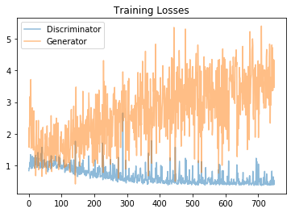

```python
fig, ax = plt.subplots()
losses = np.array(losses)
plt.plot(losses.T[0], label='Discriminator', alpha=0.5)
plt.plot(losses.T[1], label='Generator', alpha=0.5)
plt.title("Training Losses")
plt.legend()
plt.show()
```

## Generator samples from training

View samples of images from the generator, and answer a question about the strengths and weaknesses of your trained models.

```python
# helper function for viewing a list of passed in sample images
def view_samples(epoch, samples):
    fig, axes = plt.subplots(figsize=(16,4), nrows=2, ncols=8, sharey=True, sharex=True)
    for ax, img in zip(axes.flatten(), samples[epoch]):
        img = img.detach().cpu().numpy()
        img = np.transpose(img, (1, 2, 0))
        img = ((img + 1)*255 / (2)).astype(np.uint8)
        ax.xaxis.set_visible(False)
        ax.yaxis.set_visible(False)
        im = ax.imshow(img.reshape((32,32,3)))
```

```python
# Load samples from generator, taken while training
with open('train_samples.pkl', 'rb') as f:
    samples = pkl.load(f)
```

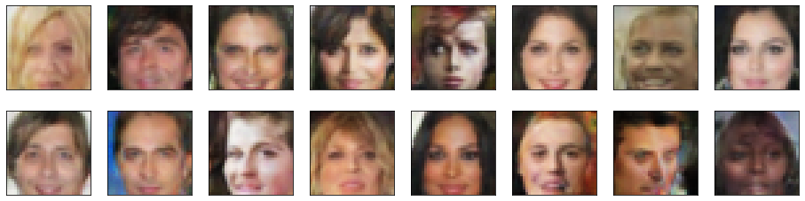

```python
_ = view_samples(-1, samples)
```

### Question: What do you notice about your generated samples and how might you improve this model?

When you answer this question, consider the following factors:

- The dataset is biased; it is made of "celebrity" faces that are mostly white
- Model size; larger models have the opportunity to learn more features in a data feature space
- Optimization strategy; optimizers and number of epochs affect your final result

### Submitting This Project

When submitting this project, make sure to run all the cells before saving the notebook. Save the notebook file as "dlnd_face_generation.ipynb" and save it as a HTML file under "File" -> "Download as". Include the "problem_unittests.py" files in your submission.